# Forest growth and dynamics (practice)

Miquel De Cáceres, Rodrigo Balaguer

Ecosystem Modelling Facility, CREAF

# Outline

1. Forest growth inputs
2. Forest growth simulations
3. Evaluation of growth predictions
4. Forest dynamics simulations
5. Forest dynamics including management

[figure not shown]

M.C. Escher - Up and down, 1947

# 1. Forest growth inputs

## Creating the forest growth input object

We assume we have an appropriate forest object:

```r
data(exampleforest)
```

a species parameter data frame:

```r
data(SpParamsMED)
```

a soil data frame:

```r
examplesoil <- defaultSoilParams(4)
```

and simulation control list:

```r
control <- defaultControl("Granier")
```

With these four elements we can build our input object for function `growth()`:

```r
x <- growthInput(exampleforest, examplesoil, SpParamsMED, control)
```

1. Forest growth inputs

## Structure of the growth input object (1)

The growth input object is a `list` with several elements:

```r
names(x)
```

```
 [1] "control"                     "soil"
 [3] "snowpack"                    "canopy"
 [5] "herbLAI"                     "herbLAImax"
 [7] "cohorts"                     "above"
 [9] "below"                       "belowLayers"
[11] "paramsPhenology"             "paramsAnatomy"
[13] "paramsInterception"          "paramsTranspiration"
[15] "paramsWaterStorage"          "paramsGrowth"
[17] "paramsMortalityRegeneration" "paramsAllometries"
[19] "internalPhenology"           "internalWater"
[21] "internalCarbon"              "internalAllocation"
[23] "internalMortality"           "internalFCCS"
[25] "internalCommunication"
```

Element `above` contains the above-ground structure data that we already know, but with an additional column `SA` that describes the estimated initial amount of *sapwood area*:

```
        SP        N   DBH Cover   H        CR          SA   LAI_live
T1_148 148 168.0000 37.55    NA 800 0.6605196 383.4520992 0.84874773
T2_168 168 384.0000 14.60    NA 660 0.6055642  47.0072886 0.70557382
S1_165 165 749.4923    NA  3.75  80 0.8032817   0.9753929 0.03062604
       LAI_expanded LAI_dead LAI_nocomp    Loading ObsID
T1_148   0.84874773        0 1.29720268 0.32447403  <NA>
T2_168   0.70557382        0 1.01943205 0.20102636  <NA>
S1_165   0.03062604        0 0.04412896 0.01407945  <NA>
```

1. Forest growth inputs

## Structure of the growth input object (2)

Elements starting with `params*` contain cohort-specific model parameters. An important set of parameters are in `paramsGrowth`:

```
          RERleaf RERsapwood  RERfineroot CCleaf CCsapwood CCfineroot
T1_148 0.01210607   5.15e-05 0.0009610199 1.5905      1.47        1.3
T2_168 0.01757808   5.15e-05 0.0072846640 1.4300      1.47        1.3
S1_165 0.02647746   5.15e-05 0.0072846640 1.5320      1.47        1.3
       RGRleafmax RGRsapwoodmax RGRcambiummax RGRfinerootmax SRsapwood
T1_148       0.09            NA   0.002628095            0.1  0.000135
T2_168       0.09            NA   0.002500000            0.1  0.000135
S1_165       0.09         0.002            NA            0.1  0.000135
        SRfineroot      RSSG fHDmin fHDmax     WoodC
T1_148 0.001897231 0.3725000     80    160 0.4979943
T2_168 0.001897231 0.9500000     40    100 0.4740096
S1_165 0.001897231 0.7804035     NA     NA 0.4749178
```

Elements starting with `internal*` contain state variables required to keep track of plant status. For example, the metabolic and storage carbon levels can be seen in `internalCarbon`:

```
       sugarLeaf starchLeaf sugarSapwood starchSapwood
T1_148 0.4029239 0.00925123    0.5738487      3.201897
T2_168 0.3585751 0.00925123    1.0741383      3.100817
S1_165 0.7223526 0.00925123    0.2857655      2.654773
```

1. Forest growth inputs

# 2. Forest growth simulations

## Forest growth run

The call to function `growth()` needs the growth input object, the weather data frame, latitude and elevation:

```r
G <- growth(x, examplemeteo, latitude = 41.82592, elevation = 100)
```

```
Initial plant cohort biomass (g/m2): 5068.34
Initial plant water content (mm): 4.73001
Initial soil water content (mm): 290.875
Initial snowpack content (mm): 0
Performing daily simulations

 Year 2001:....................................

Final plant biomass (g/m2): 5256.66
Change in plant biomass (g/m2): 188.319
Plant biomass balance result (g/m2): 188.319
Plant biomass balance components:
  Structural balance (g/m2) 104 Labile balance (g/m2) 92
  Plant individual balance (g/m2) 196 Mortality loss (g/m2) 8
Final plant water content (mm): 4.73794
Final soil water content (mm): 274.787
Final snowpack content (mm): 0
Change in plant water content (mm): 0.00793061
Plant water balance result (mm): -0.00116878
Change in soil water content (mm): -16.0878
Soil water balance result (mm): -16.0878
Change in snowpack water content (mm): 0
Snowpack water balance result (mm): 7.10543e-15
Water balance components:
  Precipitation (mm) 513 Rain (mm) 462 Snow (mm) 51
  Interception (mm) 92 Net rainfall (mm) 370
  Infiltration (mm) 400 Infiltration excess (mm) 21 Saturation excess (mm) 0 Capillarity rise (mm) 0
  Soil evaporation (mm) 26  Herbaceous transpiration (mm) 14 Woody plant transpiration (mm) 248
  Plant extraction from soil (mm) 248  Plant water balance (mm) -0 Hydraulic redistribution (mm) 4
  Runoff (mm) 21 Deep drainage (mm) 128
```

2. Forest growth

## Growth output object

Function `growth()` returns an object of class with the same name, actually a list:

```r
class(G)
```

```
[1] "growth" "list"
```

… whose elements are:

```r
names(G)
```

```
 [1] "latitude"            "topography"          "weather"
 [4] "growthInput"         "growthOutput"        "WaterBalance"
 [7] "CarbonBalance"       "BiomassBalance"      "Soil"
[10] "Snow"                "Stand"               "Plants"
[13] "LabileCarbonBalance" "PlantBiomassBalance" "PlantStructure"
[16] "GrowthMortality"
```

| Elements | Information |
| --- | --- |
| `latitude`, `topography`, `weather`, `growthInput` | Copies of the information used in the call to `growth()` |
| `growthOutput` | State variables at the end of the simulation (can be used as input to a subsequent one) |
| `WaterBalance`, `Soil`, `Snow`, `Stand`, `Plants` | [same as for function `spwb()` …] |
| `CarbonBalance` | Stand-level carbon blance |
| `LabileCarbonBalance` | Components of the individual-level labile carbon balance |
| `PlantBiomassBalance` | Components of indvidual- and cohort-level biomass balance |
| `PlantStructure` | Structural variables (DBH, height, sapwood area…) |
| `GrowthMortality` | Growth and mortality rates |

2. Forest growth

## Post-processing

Users can inspect the output of `growth()` simulations using functions `extract()`, `summary()` and `plot()` on the simulation output.

Several new plots are available in addition to those available for `spwb()` simulations (see `?plot.growth`). For example:

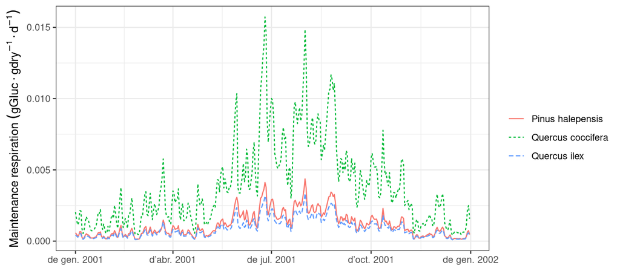

```r
plot(G, "MaintenanceRespiration", bySpecies = TRUE)
```

… but instead of typing all plots, we can call the interactive plot function `shinyplot()`.

2. Forest growth

# 3. Evaluation of growth predictions

## Observed data frame

Evaluation of growth simulations will normally imply the comparison of predicted vs observed **basal area increment** (BAI) or **diameter increment** (DI) at a given temporal resolution.

Here, we illustrate the evaluation functions included in the package using a fake data set at *daily* resolution, consisting on the predicted values and some added error.

```r
data(exampleobs)
head(exampleobs)
```

```
       dates       SWC       ETR   E_T1_148   E_T2_168 FMC_T1_148 FMC_T2_168
1 2001-01-01 0.3007733 2.2436218 0.09187857 0.14142950   125.9071   93.07915
2 2001-01-02 0.3091627 2.3236565 0.26480973 0.19095008   125.9137   93.07863
3 2001-01-03 0.2996498 0.7409083 0.15345643 0.17546363   125.8760   93.10512
4 2001-01-04 0.3042764 1.7173522 0.23470647 0.04643454   125.8643   93.07022
5 2001-01-05 0.3054886 2.0002562 0.37687792 0.10623552   125.8493   93.08487
6 2001-01-06 0.3062005 2.0722706 0.16342360 0.05550329   125.9367   93.07343
    BAI_T1_148 BAI_T2_168    DI_T1_148 DI_T2_168
1 6.222625e-06          0 9.948881e-08         0
2 3.091274e-10          0 1.071090e-11         0
3 1.298482e-13          0 0.000000e+00         0
4 2.886195e-11          0 5.552753e-13         0
5 1.287020e-03          0 1.367289e-05         0
6 1.471202e-03          0 1.000411e-05         0
```

To specify observed growth data at *monthly* or *annual scale*, you should specify the first day of each month/year (e.g. `2001-01-01`, `2002-01-01`, etc for years) as row names in your observed data frame.

3. Evaluation of growth predictions

## Evaluation plot

Assuming we want to evaluate the predictive capacity of the model in terms of monthly basal area increment for the *pine cohort* (i.e. `T1_148`), we can plot the relationship between observed and predicted values using `evaluation_plot()`:

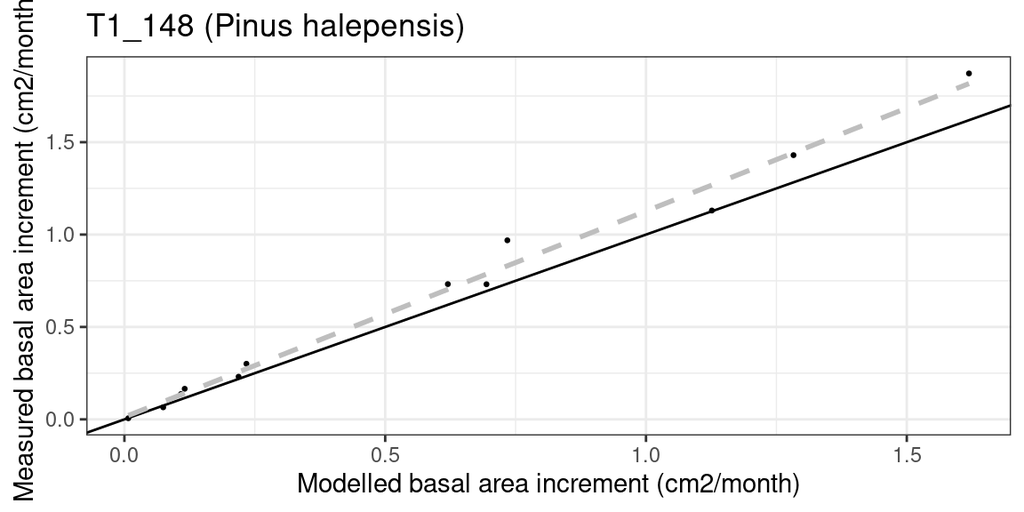

```r
evaluation_plot(G, exampleobs, "BAI",
                cohort = "T1_148",
                temporalResolution = "month",
                plotType = "scatter")
```

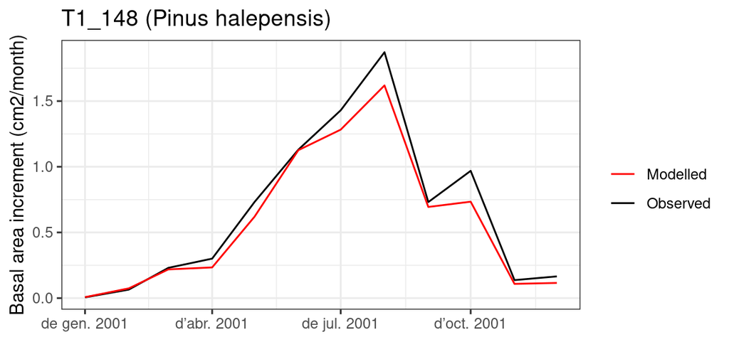

```r
evaluation_plot(G, exampleobs, "BAI",
                cohort = "T1_148",
                temporalResolution = "month",
                plotType = "dynamics")
```

Using `temporalResolution = "month"` we indicate that simulated and observed data should be temporally aggregated to conduct the comparison.

The following code would help us quantifying the *strength* of the relationship:

```r
evaluation_stats(G, exampleobs, "BAI", cohort = "T1_148", temporalResolution = "month")
```

```
           n         Bias     Bias.rel          MAE      MAE.rel            r
 12.00000000  -0.07781249 -12.01817423   0.07962016  12.29737074   0.99395785
         NSE      NSE.abs
  0.95935261   0.83966608
```

3. Evaluation of growth predictions

# 4. Forest dynamics simulations

## Forest dynamics run

**Weather preparation**

```r
meteo <- rbind(examplemeteo, examplemeteo, examplemeteo, examplemeteo)
```

we need to update the dates in row names so that they span four consecutive years:

```r
meteo$dates <- seq(as.Date("2001-01-01"),
                   as.Date("2004-12-30"), by="day")
```

**Simulation**

The call to `fordyn()` has the following form:

```r
fd<-fordyn(exampleforest, examplesoil, SpParamsMED, meteo, control,
           latitude = 41.82592, elevation = 100)
```

```
Simulating year 2001 (1/4):  (a) Growth/mortality, (b) Regeneration nT = 2 nS = 1
Simulating year 2002 (2/4):  (a) Growth/mortality, (b) Regeneration nT = 2 nS = 1
Simulating year 2003 (3/4):  (a) Growth/mortality, (b) Regeneration nT = 2 nS = 1
Simulating year 2004 (4/4):  (a) Growth/mortality, (b) Regeneration nT = 2 nS = 1
```

**Important**

- `fordyn()` operates on `forest` objects directly, instead of using an intermediary object (such as `spwbInput` and `growthInput`).
- `fordyn()` calls function `growth()` internally for each simulated year, but all console output from `growth()` is hidden.
4. Forest dynamics

## Forest dynamics output (1)

As with other models, the output of `fordyn()` is a list, which has the following elements:

| Elements | Information |
| --- | --- |
| `StandSummary`, `SpeciesSummary`, `CohortSummary` | *Annual* summary statistics at different levels |
| `TreeTable`, `ShrubTable` | Structural variables of **living** cohorts at each annual time step. |
| `DeadTreeTable`, `DeadShrubTable` | Structural variables of **dead** cohorts at each annual time step |
| `CutTreeTable`, `CutShrubTable` | Structural variables of **cut** cohorts at each annual time step |
| `ForestStructures` | Vector of `forest` objects at each time step. |
| `GrowthResults` | Result of internally calling `growth()` at each time step. |
| `ManagementArgs` | Management arguments for a subsequent call to `fordyn()`. |
| `NextInputObject`, `NextForestObject` | Objects `growthInput` and `forest` to be used in a subsequent call to `fordyn()`. |

4. Forest dynamics

## Forest dynamics output (2)

For example, we can compare the initial `forest` object with the final one:

```r
exampleforest
```

```
$treeData
           Species   N   DBH Height Z50  Z95
1 Pinus halepensis 168 37.55    800 100  600
2     Quercus ilex 384 14.60    660 300 1000

$shrubData
            Species Cover Height Z50  Z95
1 Quercus coccifera  3.75     80 200 1000

$herbCover
[1] 10

$herbHeight
[1] 20

$seedBank
[1] Species Percent
<0 files> (o «row.names» de longitud 0)

attr(,"class")
[1] "forest" "list"
```

```r
fd$NextForestObject
```

```
$treeData
           Species      DBH  Height        N Z50  Z95
1 Pinus halepensis 38.01411 824.722 166.7796 100  600
2     Quercus ilex 15.04692 673.851 382.6513 300 1000

$shrubData
            Species   Height    Cover Z50  Z95
1 Quercus coccifera 75.45527 3.237294 200 1000

$herbCover
[1] 10

$herbHeight
[1] 20

$seedBank
            Species Percent
1  Pinus halepensis     100
2      Quercus ilex     100
3 Quercus coccifera     100

attr(,"class")
[1] "forest" "list"
```

4. Forest dynamics

## Forest dynamics output (3)

The output includes **summary statistics** that describe the structural and compositional state of the forest corresponding to *each annual time step*.

For example, we can access *stand-level* statistics using:

```r
fd$StandSummary
```

```
  Step NumTreeSpecies NumTreeCohorts NumShrubSpecies NumShrubCohorts
1    0              2              2               1               1
2    1              2              2               1               1
3    2              2              2               1               1
4    3              2              2               1               1
5    4              2              2               1               1
  TreeDensityLive TreeBasalAreaLive DominantTreeHeight DominantTreeDiameter
1        552.0000          25.03330           800.0000             37.55000
2        551.3663          25.20814           806.2122             37.66571
3        550.7269          25.38321           812.4145             37.78185
4        550.0818          25.55825           818.5878             37.89804
5        549.4309          25.73315           824.7220             38.01411
  QuadraticMeanTreeDiameter HartBeckingIndex ShrubCoverLive BasalAreaDead
1                  24.02949         53.20353       3.750000    0.00000000
2                  24.12711         52.82391       3.092051    0.03917375
3                  24.22480         52.45105       3.139863    0.03983766
4                  24.32243         52.08601       3.188230    0.04050965
5                  24.41996         51.72921       3.237294    0.04118907
  ShrubCoverDead BasalAreaCut ShrubCoverCut
1    0.000000000            0             0
2    0.005308898            0             0
3    0.004784472            0             0
4    0.004858346            0             0
5    0.004933121            0             0
```

4. Forest dynamics

## Forest dynamics output (4)

Another useful output of `fordyn()` are tables in long format with cohort structural information (i.e. DBH, height, density, etc) for each time step:

```r
fd$TreeTable
```

```
   Step Year Cohort          Species      DBH   Height        N Z50  Z95 ObsID
1     0   NA T1_148 Pinus halepensis 37.55000 800.0000 168.0000 100  600  <NA>
2     0   NA T2_168     Quercus ilex 14.60000 660.0000 384.0000 300 1000  <NA>
3     1 2001 T1_148 Pinus halepensis 37.66571 806.2122 167.6992 100  600  <NA>
4     1 2001 T2_168     Quercus ilex 14.71218 663.4915 383.6671 300 1000  <NA>
5     2 2002 T1_148 Pinus halepensis 37.78185 812.4145 167.3956 100  600  <NA>
6     2 2002 T2_168     Quercus ilex 14.82398 666.9615 383.3314 300 1000  <NA>
7     3 2003 T1_148 Pinus halepensis 37.89804 818.5878 167.0890 100  600  <NA>
8     3 2003 T2_168     Quercus ilex 14.93552 670.4134 382.9928 300 1000  <NA>
9     4 2004 T1_148 Pinus halepensis 38.01411 824.7220 166.7796 100  600  <NA>
10    4 2004 T2_168     Quercus ilex 15.04692 673.8510 382.6513 300 1000  <NA>
```

**Note**

The `NA` values in `Year` correspond to the initial state.

4. Forest dynamics

## Forest dynamics output (5)

The same information can be shown for trees that are predicted to die during each simulated year:

```r
fd$DeadTreeTable
```

```
  Step Year Cohort          Species      DBH   Height         N N_starvation
1    1 2001 T1_148 Pinus halepensis 37.66571 806.2122 0.3007828            0
2    1 2001 T2_168     Quercus ilex 14.71218 663.4915 0.3328893            0
3    2 2002 T1_148 Pinus halepensis 37.78185 812.4145 0.3036490            0
4    2 2002 T2_168     Quercus ilex 14.82398 666.9615 0.3357428            0
5    3 2003 T1_148 Pinus halepensis 37.89804 818.5878 0.3065260            0
6    3 2003 T2_168     Quercus ilex 14.93552 670.4134 0.3386087            0
7    4 2004 T1_148 Pinus halepensis 38.01411 824.7220 0.3094103            0
8    4 2004 T2_168     Quercus ilex 15.04692 673.8510 0.3414840            0
  N_dessication N_burnt Z50  Z95 ObsID
1             0       0 100  600  <NA>
2             0       0 300 1000  <NA>
3             0       0 100  600  <NA>
4             0       0 300 1000  <NA>
5             0       0 100  600  <NA>
6             0       0 300 1000  <NA>
7             0       0 100  600  <NA>
8             0       0 300 1000  <NA>
```

4. Forest dynamics

## Post-processing

Accessing elements of `GrowthResults`, we can extract, summarize or plot simulation results for a particular year:

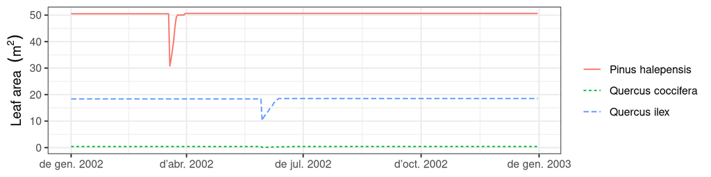

```r
plot(fd$GrowthResults[[2]], "LeafArea", bySpecies = TRUE)
```

It is also possible to plot the whole series of results by passing a `fordyn` object to the `plot()` function:

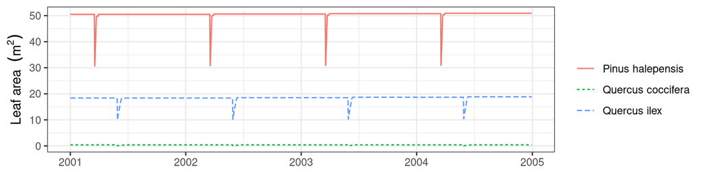

```r
plot(fd, "LeafArea", bySpecies = TRUE)
```

Finally, we can create interactive plots using function `shinyplot()`, in the same way as with other simulations.

4. Forest dynamics

# 5. Forest dynamics including management

## Running simulations with management

`fordyn()` allows the user to supply an *arbitrary* function implementing a desired management strategy for the stand whose dynamics are to be simulated.

The package includes an in-built default function called `defaultManagementFunction()` along management parameter defaults provided by function `defaultManagementArguments()`.

To run simulations with management we need to define (and modify) management arguments…

```r
# Default arguments
args <- defaultManagementArguments()
# Here one can modify defaults before calling fordyn()
#
```

… and call `fordyn()` specifying the management function and its arguments:

```r
fd<-fordyn(exampleforest, examplesoil, SpParamsMED, meteo, control,
           latitude = 41.82592, elevation = 100,
           management_function = defaultManagementFunction,
           management_args = args)
```

When management is included, tables `CutTreeTable` and `CutShrubTable` will contain extraction data:

```r
fd$CutTreeTable
fd$CutShrubTable
```

[output not shown]

5. Forest dynamics including management

## Forest management parameters (1)

Function `defaultManagementArguments()` returns a list with default values for *management parameters* to be used in conjunction with `defaultManagementFunction()`:

| Element | Description |
| --- | --- |
| `type` | Management model, either ‘regular’ or ‘irregular’ |
| `targetTreeSpecies` | Either `"all"` for unspecific cuttings or a numeric vector of target tree species to be selected for cutting operations |
| `thinning` | Kind of thinning to be applied in irregular models or in regular models before the final cuts. Options are `"below"`, `"above"`, `"systematic"`, `"below-systematic"`, `"above-systematic"` or a string … |
| `thinningMetric` | The stand-level metric used to decide whether thinning is applied, either `"BA"` (basal area), `"N"` (density) or `"HB"` (Hart-Becking index) |
| `thinningThreshold` | The threshold value of the stand-level metric causing the thinning decision |
| `thinningPerc` | Percentage of stand’s basal area to be removed in thinning operations |
| `minThinningInterval` | Minimum number of years between thinning operations |
| `finalMeanDBH` | Mean DBH threshold to start final cuts |
| `finalPerc` | String with percentages of basal area to be removed in final cuts, separated by ‘-’ (e.g. “40-60-100”) |
| `finalYearsBetweenCuts` | Number of years separating final cuts |

## Forest management parameters (2)

The same list includes *state variables* for management (these are modified during the simulation):

| Element | Description |
| --- | --- |
| `yearsSinceThinning` | State variable to count the years since the last thinning ocurred |
| `finalPreviousStage` | Integer state variable to store the stage of final cuts (‘0’ before starting final cuts) |
| `finalYearsToCut` | State variable to count the years to be passed before new final cut is applied. |

**Tip**

Instead of using the in-built management function, you could code *your own management function* and specify its *own set of parameters*!

5. Forest dynamics including management

[figure not shown]

M.C. Escher - Up and down, 1947